# Module building

A co-expression module is a group of proteins whose abundances rise and fall together across biopsies. WGCNA (Langfelder and Horvath 2008) finds them, and each module is then summarised by its eigengene: one number per biopsy that follows the module’s shared pattern. Later steps test eigengenes instead of hundreds of single proteins. Module construction never sees a group label or a phenotype.

## Packages

```r
library(here)
library(dplyr)
library(tidyr)
library(purrr)
library(ggplot2)
library(WGCNA)
source(here("00_Setup", "Shared_functions", "workbooks.R"))
disableWGCNAThreads()
inputs <- c(corrected = "01_Processing/03_Blood_Correction/c_data/blood_correction.rds")
paths <- vapply(inputs, here, character(1))
stopifnot(file.exists(paths))
```

## Input

limpa’s complete matrix with each protein’s blood slope removed from its observed values (`03_Blood_Correction`). WGCNA takes no covariate and no missing values, so this is the matrix it can use.

```r
corrected <- readRDS(paths[["corrected"]])
abund <- corrected$E
meta <- as_tibble(corrected$targets) |>
  select(sample_id, subject, group, timepoint)
stopifnot(identical(colnames(abund), meta$sample_id))
dim(abund)
```

```
[1] 2059   48
```

```r
count(count(meta, subject, name = "biopsies"), biopsies, name = "people")
```

```
# A tibble: 1 × 2
  biopsies people
     <int>  <int>
1        3     16
```

## Define modules on within-person variation

WGCNA treats every biopsy as an independent sample. These 48 biopsies come from 16 people at three time points each, and person identity drives the leading components of the abundance matrix. Left alone, modules would mostly group proteins that differ between people. So the modules are defined on person-centred abundance: each protein’s value minus that person’s mean over their three biopsies.

```r
centred <- t(apply(abund, 1, \(x) x - ave(x, meta$subject)))
expr <- t(centred)
one <- meta$sample_id[meta$subject == meta$subject[1]]
rbind(raw = round(abund[1, one], 2), centred = round(centred[1, one], 2))
```

```
        S03_T1 S03_T2 S03_T3
raw      20.97  21.47  20.96
centred  -0.16   0.33  -0.17
```

```r
dim(expr)
```

```
[1]   48 2059
```

## Soft power

WGCNA turns each pair’s correlation into a connection strength by raising it to a power (the soft power): higher powers keep strong links and shrink weak ones. The usual rule takes the lowest power whose network looks scale-free (a few proteins carry many connections, most carry few) by a fit R² of at least 0.85. Here that rule picks a power so high that the network is almost empty, so the power is set by hand:

- The fit first reaches 0.85 at power 19, where a protein has on average 1.3 connections and 73% of proteins fit no module. Zhang and Horvath (2005) warn that pushing the fit up this way leaves networks with very few connections, too little to find modules in.
- On pure noise of the same shape (2,059 features, 48 biopsies, person-centred) the fit also climbs with power (R² 0.51 at power 19) while connectivity falls towards zero, so reaching 0.85 at a high power is weak evidence of structure.
- 12 is the WGCNA FAQ’s power for signed networks with more than 40 samples, the value its author gives when the rule is met only at a higher power (support.bioconductor.org/p/93649, /p/87069, /p/124844).
- 10 is used here, with modules merged at eigengene correlation 0.75: in the settings screen below this pair gives the modules that best re-form when one person is left out (decisions log, 2026-10-28). The module QC compares powers 8, 12 and 14.

Two settings depart from the package defaults, both recommended in the WGCNA FAQ:

- a signed network, so proteins that move in opposite directions are not linked;
- biweight midcorrelation (bicor), a correlation that down-weights outlying values, with `maxPOutliers = 0.05` (the default of 1 switches that guard off). `pearsonFallback` uses an ordinary correlation for a protein with zero spread.

```r
bicor_args <- list(corType = "bicor", maxPOutliers = 0.05, pearsonFallback = "individual")
sft <- pickSoftThreshold(expr,
  powerVector = 1:22, networkType = "signed", corFnc = "bicor",
  corOptions = list(maxPOutliers = 0.05, pearsonFallback = "individual"), verbose = 0
)
```

```
   Power SFT.R.sq  slope truncated.R.sq  mean.k. median.k.  max.k.
1      1  0.54000 10.900          0.962 1120.000  1130.000 1280.00
2      2  0.24100  3.220          0.946  637.000   641.000  827.00
3      3  0.07470  1.170          0.956  375.000   376.000  551.00
4      4  0.00155  0.132          0.953  228.000   226.000  378.00
5      5  0.05860 -0.733          0.956  143.000   140.000  268.00
6      6  0.17300 -1.190          0.967   91.500    88.300  194.00
7      7  0.29400 -1.510          0.978   60.100    57.200  143.00
8      8  0.39900 -1.690          0.987   40.300    37.900  107.00
9      9  0.49400 -1.900          0.993   27.500    25.500   81.50
10    10  0.57600 -1.970          0.988   19.100    17.600   62.60
11    11  0.63400 -2.120          0.995   13.500    12.100   48.60
12    12  0.67000 -2.150          0.994    9.710     8.480   38.10
13    13  0.71300 -2.180          0.993    7.070     6.030   30.10
14    14  0.75000 -2.190          0.993    5.210     4.350   24.00
15    15  0.77400 -2.190          0.976    3.890     3.140   19.20
16    16  0.79100 -2.190          0.970    2.940     2.320   15.50
17    17  0.80700 -2.160          0.970    2.240     1.710   12.60
18    18  0.82700 -2.160          0.970    1.730     1.280   10.50
19    19  0.85100 -2.130          0.979    1.340     0.955    8.85
20    20  0.82500 -2.190          0.955    1.060     0.721    7.50
21    21  0.88800 -2.070          0.990    0.837     0.550    6.40
22    22  0.89700 -2.070          0.977    0.669     0.420    5.53
```

```r
power <- 10L
fit_indices <- as_tibble(sft$fitIndices) |>
  mutate(signed_r2 = -sign(slope) * SFT.R.sq, chosen = Power == power)
filter(fit_indices, Power %in% c(10, 12, 14, 19)) |>
  select(Power, signed_r2, mean.k., chosen)
```

```
# A tibble: 4 × 4
  Power signed_r2 mean.k. chosen
  <int>     <dbl>   <dbl> <lgl>
1    10     0.576   19.1  TRUE
2    12     0.670    9.71 FALSE
3    14     0.750    5.21 FALSE
4    19     0.851    1.34 FALSE
```

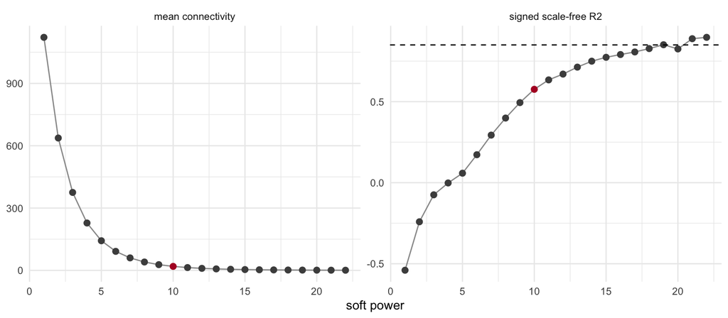

Figure 1: Connectivity and signed scale-free fit by soft power; dashed 0.85, red chosen.

```r
fit_indices |>
  select(Power, `signed scale-free R2` = signed_r2, `mean connectivity` = mean.k.) |>
  pivot_longer(-Power) |>
  ggplot(aes(Power, value)) +
  geom_line(colour = "grey60") +
  geom_point(aes(colour = Power == power), size = 2) +
  geom_hline(
    data = tibble(name = "signed scale-free R2", y = 0.85), aes(yintercept = y),
    linetype = "dashed"
  ) +
  facet_wrap(~name, scales = "free_y") +
  scale_colour_manual(values = c(`FALSE` = "grey30", `TRUE` = "#B2182B"), guide = "none") +
  labs(x = "soft power", y = NULL) +
  theme_minimal(base_size = 10)
```

## Modules

`blockwiseModules()` builds the network, measures how many neighbours each pair shares (the topological overlap, TOM), clusters proteins on it, and merges modules whose eigengenes correlate above 0.75 (`mergeCutHeight = 0.25`, the value YvO used). Proteins that fit no module go to `grey`. Settings that are not package defaults: `minModuleSize = 30` and `maxBlockSize = 2500`, which keeps all 2059 proteins in one block; the settings screen below compares them with finer splits. `randomSeed` seeds the clustering inside the function; a `set.seed()` outside it would be overridden. `build_at()` runs the whole construction, so the QC and the screen repeat it unchanged.

```r
build_at <- function(p, x = expr, deep_split = 2, min_size = 30, merge = 0.25) {
  set_names(do.call(blockwiseModules, c(
    list(x,
      power = p, networkType = "signed", TOMType = "signed", deepSplit = deep_split,
      minModuleSize = min_size, mergeCutHeight = merge, pamStage = TRUE,
      pamRespectsDendro = TRUE, maxBlockSize = 2500, numericLabels = FALSE, randomSeed = 54321,
      verbose = 0
    ),
    bicor_args
  ))$colors, colnames(x))
}
colours <- build_at(power)
sort(table(colours), decreasing = TRUE)
```

```
colours
turquoise      blue     brown      grey    yellow     green       red     black
      340       330       249       229       211       168       167       109
     pink   magenta    purple
      104        82        70
```

At power 10 a protein has on average 19.1 connections and 11% of proteins fit no module.

## Module QC: how much the power matters

The same construction at powers 8, 12 and 14, compared with power 10 by WGCNA’s `overlapTable()`: for each power-10 module, the share of its proteins that land in its best-matching module at the other power. A module that keeps most of its proteins at 8 and 12 does not depend on the exact power.

```r
module_qc <- map(set_names(c(8, 12, 14)), \(p) {
  other <- build_at(p)
  overlap <- overlapTable(colours, other)$countTable
  overlap <- overlap[rownames(overlap) != "grey", colnames(overlap) != "grey", drop = FALSE]
  tibble(
    module = rownames(overlap), n_proteins = as.vector(table(colours)[rownames(overlap)]),
    kept_share = apply(overlap, 1, max) / n_proteins,
    n_modules_other = n_distinct(other[other != "grey"]), grey_other = sum(other == "grey")
  )
}) |>
  list_rbind(names_to = "power_other")
module_qc |>
  summarise(
    modules = first(n_modules_other), grey = first(grey_other),
    median_kept = round(median(kept_share), 2), .by = power_other
  )
```

```
# A tibble: 3 × 4
  power_other modules  grey median_kept
  <chr>         <int> <int>       <dbl>
1 8                11   218        0.77
2 12               12   283        0.7
3 14                9   544        0.7
```

## Settings screen: do modules re-form without one person?

With 16 people, a module that one person’s three biopsies make or break is not a property of muscle. The screen builds each of 32 settings on everyone and 16 more times with one person left out: power 10 or 12, merge height 0.15 or 0.25, deepSplit 2 or 3, minimum size 20 or 30, and all proteins or only those observed in at least 36 of 48 biopsies. A full-data module re-forms in a fold when its best-matching fold module shares at least half its proteins (Jaccard >= 0.5, the YvO rule); its stability is the median of those best matches over the 16 folds. Finer splits (deepSplit 3, minimum 20) re-form less often, so the modules here are kept coarse. A scratch run with uncentred input gave similar trade-offs.

```r
observed <- rowSums(corrected$other$n.observations > 0)
members <- \(colours) split(names(colours), colours)[setdiff(unique(colours), "grey")]
best_jaccard <- function(full, fold) {
  map_dbl(full, \(m) max(map_dbl(fold, \(f) length(intersect(m, f)) / length(union(m, f))), 0))
}
stability_of <- function(p, x = expr, ...) {
  full <- members(build_at(p, x, ...))
  folds <- map(unique(meta$subject), \(s) members(build_at(p, x[meta$subject != s, ], ...)))
  jaccard <- do.call(cbind, map(folds, \(f) best_jaccard(full, f)))
  tibble(
    module = names(full), n_proteins = lengths(full), stability = apply(jaccard, 1, median),
    reform_share = rowMeans(jaccard >= 0.5)
  )
}
screen_grid <- expand_grid(
  proteins = c("all", "observed_36"), power = c(10, 12), merge = c(0.15, 0.25),
  deep_split = 2:3, min_size = c(20, 30)
)
settings_screen <- parallel::mclapply(seq_len(nrow(screen_grid)), \(g) {
  s <- screen_grid[g, ]
  x <- if (s$proteins == "all") expr else expr[, observed >= 36]
  stability_of(s$power, x, deep_split = s$deep_split, min_size = s$min_size, merge = s$merge) |>
    summarise(
      n_modules = n(), share_in_modules = sum(n_proteins) / ncol(x),
      median_stability = median(stability), n_reforming = sum(stability >= 0.5)
    ) |>
    bind_cols(s, n_tested = ncol(x))
}, mc.cores = max(1, parallel::detectCores() - 1)) |>
  list_rbind() |>
  relocate(proteins, power, merge, deep_split, min_size, n_tested) |>
  mutate(
    chosen = proteins == "all" & power == 10 & merge == 0.25 & deep_split == 2 & min_size == 30
  ) |>
  arrange(desc(median_stability))
stopifnot(sum(settings_screen$chosen) == 1)
head(settings_screen, 8)
```

```
# A tibble: 8 × 11
  proteins   power merge deep_split min_size n_tested n_modules share_in_modules
  <chr>      <dbl> <dbl>      <int>    <dbl>    <int>     <int>            <dbl>
1 all           10  0.25          2       30     2059        10            0.889
2 all           12  0.15          2       30     2059        13            0.863
3 observed_…    12  0.25          3       30     1509        15            0.922
4 all           10  0.15          2       30     2059        12            0.889
5 all           12  0.25          3       30     2059        13            0.864
6 observed_…    12  0.25          2       30     1509        13            0.913
7 all           12  0.25          2       30     2059        12            0.863
8 observed_…    10  0.25          2       30     1509        11            0.925
# ℹ 3 more variables: median_stability <dbl>, n_reforming <int>, chosen <lgl>
```

The modules used here, one by one:

```r
module_stability <- stability_of(power)
stopifnot(setequal(module_stability$module, setdiff(unique(colours), "grey")))
arrange(module_stability, desc(stability))
```

```
# A tibble: 10 × 4
   module    n_proteins stability reform_share
   <chr>          <int>     <dbl>        <dbl>
 1 black            109     0.691        1
 2 brown            249     0.647        0.938
 3 red              167     0.600        0.625
 4 blue             330     0.531        0.5
 5 purple            70     0.522        0.625
 6 turquoise        340     0.520        0.688
 7 pink             104     0.512        0.562
 8 green            168     0.434        0.312
 9 magenta           82     0.272        0
10 yellow           211     0.237        0
```

## Eigengenes and membership

The eigengene is the first principal component of a module’s proteins, scored here on the uncentred matrix so that differences between people, and so between HR and LR, stay testable. `moduleEigengenes()` flips each eigengene’s sign to follow the module’s average abundance (package default).

```r
me <- moduleEigengenes(t(abund), colors = colours, excludeGrey = TRUE)$eigengenes
rownames(me) <- colnames(abund)
eigengenes <- t(as.matrix(me))
rownames(eigengenes) <- sub("^ME", "", rownames(eigengenes))
dim(eigengenes)
```

```
[1] 10 48
```

```r
round(eigengenes[1:3, 1:4], 3)
```

```
      S03_T1 S03_T2 S03_T3 S04_T1
black  0.308 -0.074  0.043  0.013
blue  -0.169 -0.006  0.195  0.050
brown  0.282 -0.027 -0.018 -0.039
```

A protein’s kME is its correlation with its module’s eigengene: near 1 means it follows the module closely. kME is read on the person-centred data that defined the modules, because on uncentred data the differences between people dilute it. The gene is the first symbol limpa gives the protein.

```r
centred_me <- moduleEigengenes(expr, colors = colours, excludeGrey = TRUE)$eigengenes
kme <- signedKME(expr, centred_me,
  corFnc = "bicor", corOptions = "maxPOutliers = 0.05, pearsonFallback = 'individual'"
)
colnames(kme) <- sub("^kME", "", colnames(kme))
membership <- tibble(
  uniprot_id = names(colours),
  gene = sub(";.*", "", corrected$genes[names(colours), "Genes"]),
  module = unname(colours)
) |>
  mutate(kme = map2_dbl(uniprot_id, module, \(id, m) if (m == "grey") NA_real_ else kme[id, m]))
membership |>
  filter(module != "grey") |>
  slice_max(kme, n = 2, by = module) |>
  arrange(module) |>
  head(6)
```

```
# A tibble: 6 × 4
  uniprot_id gene   module   kme
  <chr>      <chr>  <chr>  <dbl>
1 P20929     NEB    black  0.950
2 P35609     ACTN2  black  0.930
3 P61160     ACTR2  blue   0.863
4 Q00839     HNRNPU blue   0.858
5 Q13619     CUL4A  brown  0.867
6 Q96I23     PYURF  brown  0.867
```

## How much each eigengene still depends on the person

The intraclass correlation (ICC) is the share of an eigengene’s variance that lies between people rather than between one person’s biopsies, from a mixed model with time point fitted (lme4, `eigengene ~ timepoint + (1 | subject)`), so time effects do not count as noise.

```r
eigengene_long <- as_tibble(t(eigengenes), rownames = "sample_id") |>
  pivot_longer(-sample_id, names_to = "module", values_to = "eigengene") |>
  left_join(meta, by = "sample_id")
subject_icc <- eigengene_long |>
  summarise(
    icc = {
      v <- as.data.frame(lme4::VarCorr(suppressMessages(
        lme4::lmer(eigengene ~ timepoint + (1 | subject))
      )))$vcov
      v[1] / (v[1] + v[2])
    },
    .by = module
  )
module_summary <- count(filter(membership, module != "grey"), module, name = "n_proteins") |>
  left_join(subject_icc, by = "module") |>
  arrange(desc(n_proteins))
module_summary
```

```
# A tibble: 10 × 3
   module    n_proteins    icc
   <chr>          <int>  <dbl>
 1 turquoise        340 0.0947
 2 blue             330 0.0859
 3 brown            249 0.0203
 4 yellow           211 0.119
 5 green            168 0
 6 red              167 0.268
 7 black            109 0.137
 8 pink             104 0.208
 9 magenta           82 0.0227
10 purple            70 0.139
```

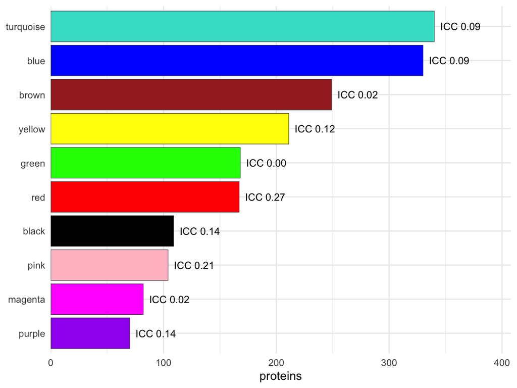

Figure 2: Proteins per module, labelled with the eigengene’s person ICC.

```r
module_colours <- set_names(module_summary$module, module_summary$module)
module_summary |>
  mutate(module = factor(module, levels = rev(module))) |>
  ggplot(aes(n_proteins, module, fill = module)) +
  geom_col(colour = "grey30", linewidth = 0.2) +
  geom_text(aes(label = sprintf("ICC %.2f", icc)), hjust = -0.15, size = 3) +
  scale_fill_manual(values = module_colours, guide = "none") +
  scale_x_continuous(expand = expansion(mult = c(0, 0.2))) +
  labs(x = "proteins", y = NULL) +
  theme_minimal(base_size = 10)
```

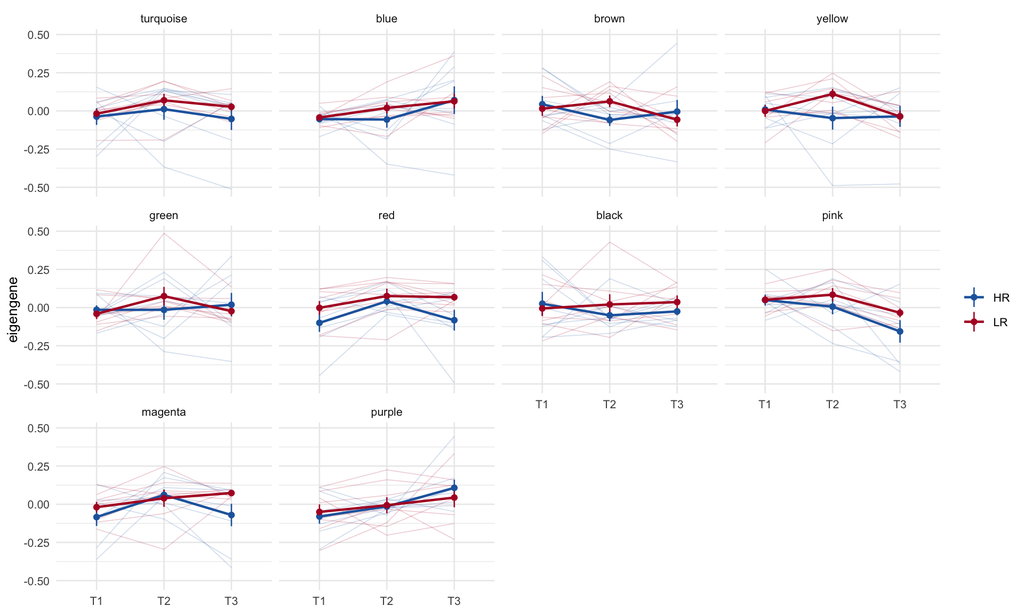

Figure 3: Eigengene per biopsy. Thin lines: one person. Thick line and range: group mean ± SE.

```r
trajectory <- eigengene_long |>
  summarise(
    mean = mean(eigengene), se = sd(eigengene) / sqrt(n()),
    .by = c(module, group, timepoint)
  )
ggplot(trajectory, aes(timepoint, mean, colour = group, group = group)) +
  geom_line(
    data = eigengene_long, aes(y = eigengene, group = subject),
    alpha = 0.2, linewidth = 0.3
  ) +
  geom_line(linewidth = 0.8) +
  geom_pointrange(aes(ymin = mean - se, ymax = mean + se), size = 0.25) +
  facet_wrap(~ factor(module, levels = module_summary$module)) +
  scale_colour_manual(values = c(HR = "#2166AC", LR = "#B2182B"), name = NULL) +
  labs(x = NULL, y = "eigengene") +
  theme_minimal(base_size = 10)
```

## Validation

```r
stopifnot(
  identical(colnames(eigengenes), meta$sample_id),
  setequal(rownames(eigengenes), setdiff(unique(colours), "grey")),
  all(abs(membership$kme[membership$module != "grey"]) <= 1),
  sum(module_summary$n_proteins) + sum(colours == "grey") == nrow(abund),
  !anyNA(membership$gene)
)
```

## Summary

```r
at_power <- filter(fit_indices, Power == power)
select(at_power, Power, signed_r2, mean.k.)
```

```
# A tibble: 1 × 3
  Power signed_r2 mean.k.
  <int>     <dbl>   <dbl>
1    10     0.576    19.1
```

Soft power 10 (signed R² 0.576, mean connectivity 19.1). 10 modules of 70 to 340 proteins; 229 of 2059 proteins fit no module. Module colours are labels only and change if `01_Processing` is rebuilt.

## Save

`module_building.rds` holds the eigengenes (module by biopsy), the membership with kME, the biopsy table (`meta`) and the module summary; every module-level step reads it.

```r
out <- here("01_Processing", "06_Module_Building", "c_data")
dir.create(out, showWarnings = FALSE)
saveRDS(
  list(
    eigengenes = eigengenes, membership = membership, meta = meta, module_summary = module_summary
  ),
  file.path(out, "module_building.rds"),
  compress = "xz"
)
sheets <- list(
  module_summary = module_summary, membership = membership,
  eigengenes = as_tibble(t(eigengenes), rownames = "sample_id"),
  soft_threshold = fit_indices, module_qc = module_qc, settings_screen = settings_screen,
  module_stability = module_stability
)
holds <- c(
  "Proteins per module and the subject ICC of its eigengene.",
  "Every protein's module and its kME in that module.",
  "Module eigengene per biopsy, scored on uncentred abundance.",
  "pickSoftThreshold fit indices per power; chosen marks the power used (10).",
  "Per power-10 module: share of its proteins kept in its best match at powers 8, 12 and 14.",
  "Per construction setting: modules and their leave-one-person-out stability; chosen marks ours.",
  "Per module used: median best Jaccard over 16 leave-one-person-out refits, share re-forming."
)
write_workbook(sheets, holds, file.path(out, "module_building.xlsx"), inputs, paths)
```